# GeoScanning Code Base

Michael Fichman for PennPraxis

October 14, 2019

# 1. Overview

This document details the code used to intake, clean and analyze geo-location data from the GeoScanning project subjects, spatially relate it to retailer locations and summarize and analyze it according to parameters to be specified.

During the summer and fall of 2019, Michael Fichman, city planning researcher and analyst at PennPraxis (of the Weitzman School of Design), took pre-existing codebase developed for the project and updated it to conform (where possible) to modern `tidyverse` data wrangling standards and the powerful `sf` spatial package which is integrated in to the `tidyverse` and R’s powerful visualization package `ggplot2`.

At the present date, this is a document-in-progress and the code contained heirein is designed to operate on test geo data and a temporary data set of tobacco retailer locations. Subsequent steps to code base development will include the creation of a suite of descriptive statistics for standard data intake and analysis procedures, the creation of an interactive map as part of a subject intake protocol and the development of a “spatial risk surface” analytic approach. Furthermore, retailer information for a multi-state study area will need to be run through the protocol.

## 1.1. About this code base

The tidyverse is [‘a set of packages that work in harmony because they share common data representations and API design. The tidyverse package is designed to make it easy to install and load core packages from the tidyverse in a single command.’](https://blog.rstudio.com/2016/09/15/tidyverse-1-0-0/). The tidyverse is notable for two reasons - first because it is designed to work strictly with flat files - dataframes or tibbles. Second because it eschews for-looping in favor of a set of functions in the package dplyr which effectively replace bespoke loops. Third because it has a more efficient data cleaning syntax than base R - it uses the %>% operator, known as a ‘pipe’ to pass a dataframe from function to function instead of base R’s syntax which involves either creating lots of nested parentheses or intemediate data objects.

This process will generate a more flexible code base - harder to use without a surface understanding of R, but much more adaptable to new intake data types and structures, updates and new analyses. For example, this code will have fewer tightly written functions that can be simply executed, but are very difficult to troubleshoot in the event of bad data or changes to the programming language.

That said, the new code, as with the old code, is open source and subject to deprecation, package updates etc., This document is designed to annotate the code base to be understandable, reproducible and reflective of research needs.

## 1.2. Using R Markdown

This document is [an R Markdown document](https://bookdown.org/yihui/rmarkdown/), which is a publishing language designed embed chunks of R code. It can also be used to create reproducible reports undergirded by R code.

Code can be cut and pasted from this document into a regular R code file or the R console.

Use the table of contents at the left hand side to navigate through this document.

## 1.3. The Nature and Structure of the Data

The data being used in this study are of two types - geotracking data collected from subject phones and retailer location data being collected from licensing databases. Both data types have their own quirks and liabilities.

Test geolocation data being used for this study was previously in kml file format, but not a kml format that has proved readable with standard kml drivers for popular software such as ArcGIS or the `sf` spatial package in R. Therefore, these data within the kml file itself need to be parsed.

Alternatively, json exports are fairly easy to use - it is suggested that users export files in json format. This code reflects the assumption that json will be the preferred data type.

Retailer data is administrative - not well suited for research purposes. It also appears to be incomplete and will need to be patched up.

# 2. Set up

Prior to data intake and processing, packages, graphic styling, API key codes and other information should be set up to enable proper execution of the code which follows.

## 2.1. Load Libraries

`tidyverse` - R’s mutually intelligible world of data-wrangling and graphics packages including `dplyr`

`sf` - The premier spatial package for R, which plays well with `ggplot2`, `dplyr` and the other tidyverse packages. Includes geoprocessing capabilities for point and polygon geometries.

`tigris` - A package for calling shapefiles from the US Dept. of Commerce, including political boundaries, school districts and hydrology

`tidycensus` - A `tidy` and `sf` compatible package for calling the US Census API for any available data from the ACS and decennial census, 2000 to present. Includes geometries from tracts to counties to states if desired.

`viridis` - Color palettes for data vizualization

`lubridate` - A sophisticated yet simple date-handling package

`mapview` - A dynamic mapping package, similar to leaflet, that accepts `sf` objects. Fairly janky, ill-supported and best used for internal visualizations rather than public presentation.

`ggmap` - An older mapping graphics package designed for use with ggplot, which has been surpassed by `sf` but allows for geocoding to APIs such as Google Maps and the Data Science Toolkit.

`jsonlite` - A package designed to upload, convert and handle JSON files in R

`RSocrata` - A package used to interact with APIs commonly used to host open data sets. Pennsylvania and NJ use “SODA” - the Socrata Open Data API as an endpoint for its data.

```r
library(tidyverse)
library(sf)
library(tigris)
library(tidycensus)
library(viridis)
library(lubridate)
library(mapview)
library(ggmap)
library(jsonlite)
library(RSocrata)
```

## 2.2. Create Graphic Styling

Load a set of themes for publishable maps and plots known here as `plotTheme` and `mapTheme`. These can be added to `ggplot2` scripts and serve a whole set of style elements including element sizes, angles, gridlines etc.,

```r
plotTheme <- theme(
  plot.title =element_text(size=12),
  plot.subtitle = element_text(size=8),
  plot.caption = element_text(size = 6),
  axis.text.x = element_text(size = 10, angle = 45, hjust = 1),
  axis.text.y = element_text(size = 10),
  axis.title.y = element_text(size = 10),
  # Set the entire chart region to blank
  panel.background=element_blank(),
  plot.background=element_blank(),
  # Format the grid
  panel.grid.major=element_line(colour="#D0D0D0",size=.75),
  axis.ticks=element_blank())

mapTheme <- theme(plot.title =element_text(size=12),
                  plot.subtitle = element_text(size=8),
                  plot.caption = element_text(size = 6),
                  axis.line=element_blank(),
                  axis.text.x=element_blank(),
                  axis.text.y=element_blank(),
                  axis.ticks=element_blank(),
                  axis.title.x=element_blank(),
                  axis.title.y=element_blank(),
                  panel.background=element_blank(),
                  panel.border=element_blank(),
                  panel.grid.major=element_line(colour = 'transparent'),
                  panel.grid.minor=element_blank(),
                  legend.direction = "vertical",
                  legend.position = "right",
                  plot.margin = margin(1, 1, 1, 1, 'cm'),
                  legend.key.height = unit(1, "cm"), legend.key.width = unit(0.2, "cm"))

palette <- c("#10142A", "#47E9B9", "#F55D60", "#71EA48", "#C148EA", "EAC148" )
```

## 2.3. Load Census API Key

For spatial joins of geotracking information to census geographies (and census demographic data), one can use the `tidycensus` package, but only with a key or token from the US Census Bureau. The code block below demonstrates the loading of one’s key - this is Michael Fichman’s key, please get your own and insert it into the `census_api_key` function below.

You can get your own key quickly via this [link](https://api.census.gov/data/key_signup.html). Presently, the Commerce Dept and Census Bureau have been somewhat less than reliable creating keys though, it’s unclear the reasons for this.

```r
# Install Census API Key
census_api_key("e79f3706b6d61249968c6ce88794f6f556e5bf3d", overwrite = TRUE)
```

## 2.4. Set Working Directory

Use the `setwd` to specify a working directory on your computer, server or the like. This command is repeated at various points in the script to point the program to different locations where assorted data is read or written.

The example code block below connects to a folder on the PennPraxis and Weitzman School of Design password-protected server space. The code block below should be changed to reflect your top-level folder for your file tree on a password protected server.

Ultimately, the file tree should contain sub folders for input data, output graphics and output data. Such folders are referenced throughout this codebase - please pay attention to file nomenclature used in the codeblocks.

```r
setwd("//jove.design.upenn.edu/Dept-Shares/prax/01 Project Folders/2019_Annenberg_GeoScanning/")
```

# 3. Load Data

Whereas previous versions of this code base used kml data exported from phones, these data were persistently problematic in their operability with common spatial data drivers and required elaborate text parsing prone to opaque errors that would be difficult for an intermediate R user to diagnose.

The routines described in this section are designed to fetch multiple JSON files from a **single folder**, convert each file structure to a preferrable “flat” structure, and append all of the files together, with user/file name attached to indicate subject ID.

It is much simpler to use JSON data from google maps geotracking software than it is to use KML data. Functions to use kml data are included in an appendix to this document - we have developed them, but for various reasons, they are not recommended for use at this time because of some odd problems with these data exports.

R operates primarily with “flat” files like CSVs etc., wheras JSONs are nested. `fromJSON` from the `jsonlite` packages is designed to load, convert and handle JSONs and turn them into something workable in R - a data frame.

## 3.1. Load JSON data

We create a function called `loadJSON` which uses `fromJSON` to call a single JSON file, simplify it to a data frame and “flatten” it. The only argument this function takes is a file name `jsonFilename`.

The function subsequently handles latitude, longitude and date information and exports a file which contains a date, lat/lon information alongside measures of accuracy, velocity and altitude contained in the original JSON.

```r
loadJSON <- function(jsonFilename){fromJSON(jsonFilename,
                                            simplifyDataFrame = TRUE,
                                            flatten = TRUE)%>%
    .[1] %>%
    as.data.frame() %>%
    mutate(lat = locations.latitudeE7 / 1e7, # put the decimal in the right place for the lat
           lon = locations.longitudeE7 / 1e7, # put the decimal in the right place for the lat
           datetime = as.POSIXct(as.numeric(locations.timestampMs)/1000, # go from unix time to POSIXct date time
                                 origin = "1970-01-01")) %>%
    select(datetime, lat, lon, locations.altitude,
           locations.velocity, locations.accuracy) # select only what you need

}
```

We create an object called `paths` using the function `dir` to identify all filepaths for jsons (`pattern = "\\.json$"`) in a specific location.

Recall we used the `setwd` command to establish a top level working directory, and this first argument to `dir` should be the filepath **after** the top level working directory name you established. So no need for any “C://myName/myfolder” etc at the beginning, just the subsidiary folders.

Presently this filepath leads to a specific subfolder where two test JSON outputs are located.

We can also create a vector where the `basename` e.g. the filename of each file is substituted for the arbitrary, numerical ’names` for each file.

```r
setwd("//jove.design.upenn.edu/Dept-Shares/prax/01 Project Folders/2019_Annenberg_GeoScanning/")
paths <- dir("inputData/Test kml and json timeline data/Test kml and json timeline data/multi_json_test", pattern = "\\.json$", full.names = TRUE)

names(paths) <- basename(paths)
```

We then use the `map_dfr` function from the `tidyverse`’s `purrr` library to “map” (e.g. apply without looping) the dataframe format to each file in our `paths` object and then append their rows as a data frame. Our resulting dataframe is called `myData`.

```r
setwd("//jove.design.upenn.edu/Dept-Shares/prax/01 Project Folders/2019_Annenberg_GeoScanning/")
myData <- map_dfr(paths, loadJSON, .id = "filename")
```

We can take a look at `myData` using the `glimpse` command.

```r
glimpse(myData)
```

```
## Observations: 1,540
## Variables: 7
## $ filename           <chr> "file1.json", "file1.json", "file1.json", "...
## $ datetime           <dttm> 2018-09-12 15:40:03, 2019-04-09 16:08:13, ...
## $ lat                <dbl> 39.94952, 39.95307, 39.95308, 39.95284, 39....
## $ lon                <dbl> -75.19778, -75.19585, -75.19575, -75.20450,...
## $ locations.altitude <int> 22, 25, 25, 33, 26, 29, 21, 22, 22, 23, 25,...
## $ locations.velocity <int> NA, NA, NA, NA, NA, NA, NA, NA, NA, 0, 0, 0...
## $ locations.accuracy <int> 65, 65, 65, 65, 50, 65, 65, 65, 65, 10, 10,...
```

## 3.2. Select For Relevant Dates, De-identify and Remove Original Data

We can now do date cleaning and deidentification to prepare the data for analysis.

We may have to have some `ifelse` or `case_when` statements for different batches of study times and subject IDs so that we can only select relevant dates and times that apply to the study. We can then `remove` our original data frame `myData`, leaving only the cleaned data for analysis.

See the `case_when` statement below - essentially this is saying that the variable `keep`, which is initially set to 0, should be a 1 when `datetime` is greater than a certain date and time and less than some other date and time.

For our test data, we just strip out a few observations at the beginning and end to demonstrate the technique.

This could also be engineered to take a separate csv with a date range for each filename so that this can be done mechanically.

The `datetime` format is “year-month-day hour:minute:second” input as a string.

```r
cleanData <- myData %>%
  mutate(keep = case_when(filename == "file1.json" &
                            datetime > "2019-04-22 21:30:45" &
                            datetime < "2019-08-05 15:17:47" ~ 1,
                          filename == "file2.json" &
                            datetime > "2019-04-22 21:30:45" &
                            datetime < "2019-08-05 15:17:47" ~ 1)) %>%
  filter(is.na(keep) == FALSE)%>%
  select(-keep)
```

At this point, one may write out `cleanData` and remove the original data set (using the `remove` command) from the workspace.

```r
write.csv(cleanData, "myfilepath.csv")

remove(myData)
```

## 3.3. Convert to sf Simple Features Object

The `sf` (or simple features) package is the most robust vector-based GIS package in R. It handles geojson, shapefiles and other major spatial data types and performs projection, geoprocessing and other functions within the `tidyverse` data wrangling framework. Most of the normal operations that can be performed on a dataframe can be performed on an sf object. The only major difference between a dataframe and an sf object is that an sf object has a `geometry` column which prescribes its geometry, be it point, line or ploygon.

We begin by taking our `cleanData` data frame, filtering out observations that lack a latitude or longitude reading and use the `st_as_sf` function to create a point `sf` object, specifying the geographic (e.g. unprojected) coordinate system WGS84 aka “web mercator” using the `crs` argument and the recognized reference number for that system, 4326.

```r
cleanData <- cleanData %>%
  filter(is.na(lat) == FALSE & is.na(lon) == FALSE) %>%
  st_as_sf(., coords = c("lon", "lat"), crs = 4326)
```

WGS84 uses lat/lon decimal degrees, and any geoprocessing that you do which requires linear units of distance (feet, meters etc.,) will require projection first. There are projected coordinate systems for Southeastern PA and its environs used by government geographic agencies, the most common being North American Datum 1983 (NAD83), PA State Plane South, which has crs number 2272 and is projected in feet.

More information about projections and their reference numbers can be found at [‘spatialreference.org.’](https://spatialreference.org)

# 4. Load Study Area Geometries

We can create a list of county names for the Philadelphia / Delaware Valley region, and use this vector to both call spatial data from the census using the `tigris` package, but also to use as filtering criteria later for our retailer locations. This vector is spelling and case sensitive.

```r
countyList <- c('Philadelphia', 'Delaware', 'Bucks', 'Montgomery',
                'Chester', 'New Castle', 'Burlington', 'Camden',
                'Gloucester', 'Salem', 'Cumberland', 'Berks',
                'Lancaster', 'Mercer', 'Salem', 'Atlantic', 'Monmouth',
                'Kent')
```

Using the `counties` function in the `tigris` package, we call the shapefiles for all of PA, NJ and DE from the Census Bureau’s API, reproject it to WGS84, Web Mercator and then filter for names in the `countyList` vector we created.

```r
counties <- counties(c('PA', 'NJ', 'DE')) %>%
  st_as_sf()%>%
  st_transform(crs=4326) %>%
  filter(NAME %in% countyList)
```

# 5. Explore Geolocation Data

We can explore our data using a number of routines to understand our sample’s date range, time-space elements, sampling rate, subject’s interpolated speed. daily and weekly patterns and more.

## 5.1. Timeseries of observations by subject

Data volume can be examined spatially and temporally by subject. This can be done by facetting time-series data by subject or by plotting multiple subjects on one time series. The more subjects you have, the messier this can get.

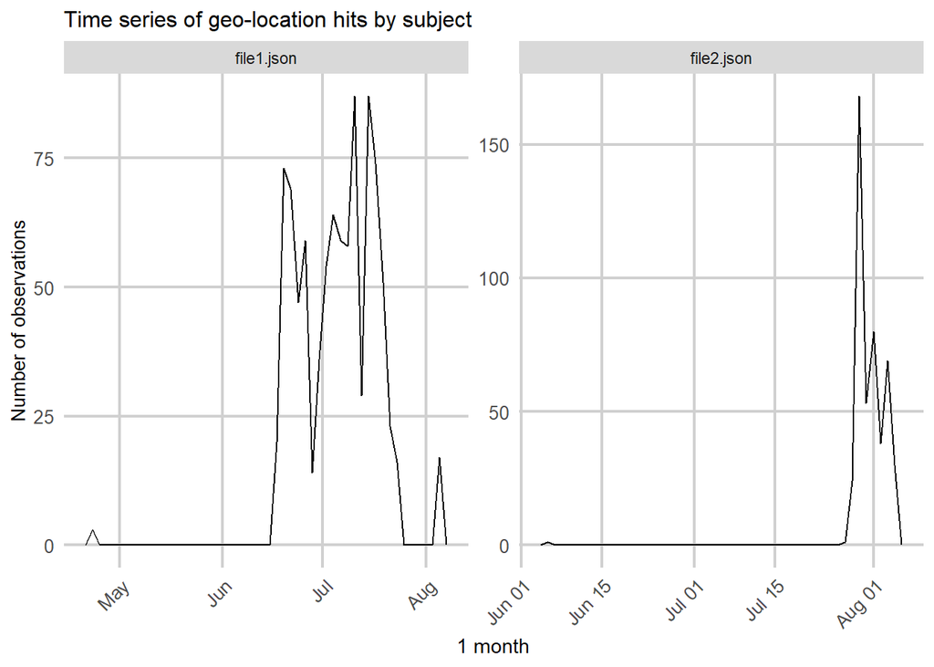

```r
ggplot(cleanData, aes(as.Date(datetime)))+
    geom_freqpoly(bins = 50) +
    scale_x_date((date_breaks = "1 month"))+
    facet_wrap(~filename, scales = "free")+
    labs(
        title = "Time series of geo-location hits by subject",
        y = "Number of observations",
        x = "Date (1 month bins)")+
    plotTheme
```

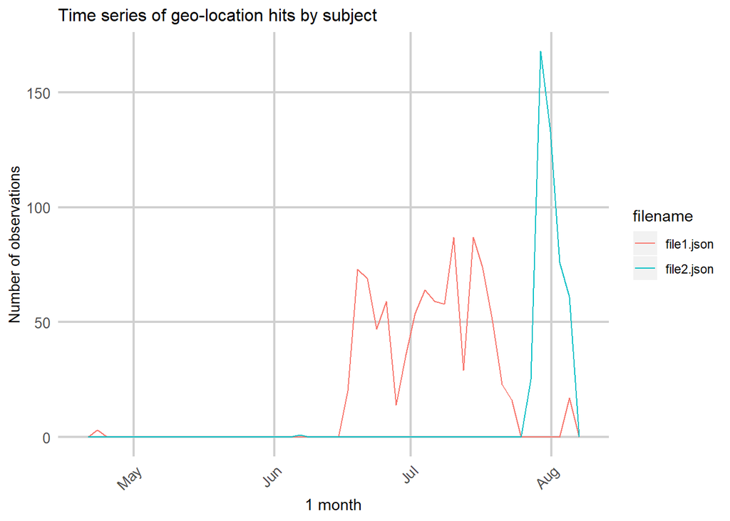

```r
ggplot(cleanData, aes(as.Date(datetime)))+
    geom_freqpoly(aes(color = filename), bins = 50) +
    scale_x_date((date_breaks = "1 month"))+
    labs(
        title = "Time series of geo-location hits by subject",
        y = "Number of observations",
        x = "Date")+
    plotTheme
```

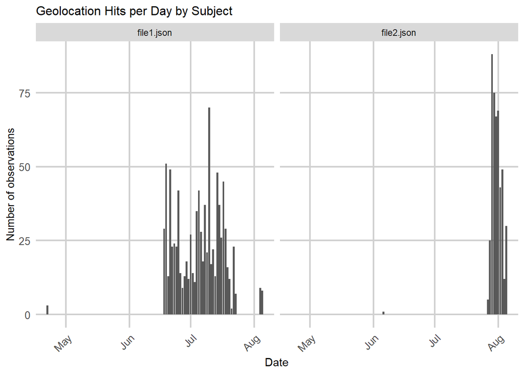

```r
ggplot(cleanData %>%
         mutate(intervalDaily = floor_date(ymd_hms(datetime), unit = "1 day")) %>%
         group_by(intervalDaily, filename)%>%
         tally())+
  geom_bar(aes(x = intervalDaily, y = n), stat = "identity")+
  facet_wrap(~filename)+
  labs(
        title = "Geolocation Hits per Day by Subject",
        y = "Number of observations",
        x = "Date")+
  plotTheme
```

## 5.2. Spatial extent of data

We can examine the spatial extent of our data, but we may have to downsample using the dplyr verb `sample_n()` when we do (plotting too many vector points might make your computer unhappy).

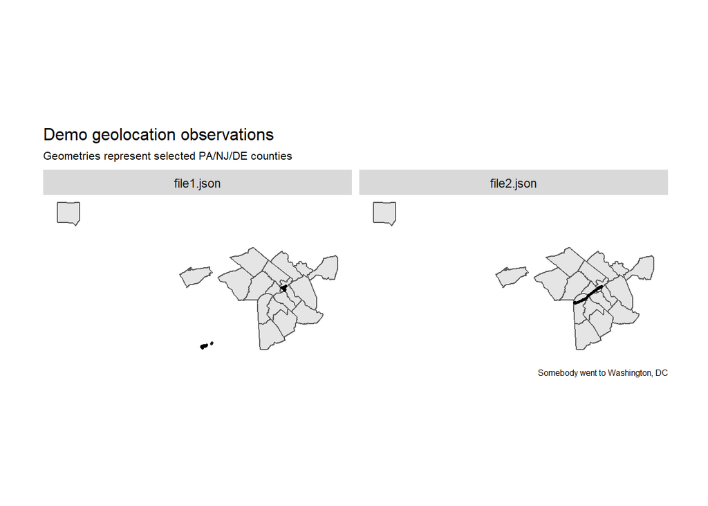

```r
ggplot()+
  geom_sf(data = counties)+
  geom_sf(data = cleanData, alpha = 0.75, size = 0.5)+
  labs(
    title = "Demo geolocation observations",
    subtitle = "Geometries represent selected PA/NJ/DE counties",
    caption = "Somebody went to Washington, DC")+
  facet_wrap(~filename)+
  mapTheme
```

## 5.3. Create time and space lags and estimate speed

There are several reasons to take time and distance lag measurements. First, the original data have a velocity estimate, but much of this data is `NA` -if we create our own velocity estimates we can have an additional (and perhaps better) way to determine when our subjects are in transit past an exposure site at automobile speed - or actually walking past one or inside one.

These lag measurements are done by transforming our data to `crs = 2272` - a projection in feet, and measuring the distance between x-y points from observation to observation.

We create several variables here:

`lagDist` - lagged distance in feet from the previous observation

`lagTime` - lagged time in seconds from the previous observation

`lagmph` - the miles per hour measured from the previous observation

`lead_lag_avg_mph` - the average of the miles per hour from the previous observation and the miles per hour to the next observation

`mean_3_lagDist_ft` - the mean of the 3 previous distance lags for a given observation

```r
cleanData <- cleanData %>%
    ungroup() %>%
    st_transform(crs = 2272) %>%
    mutate(lon=map_dbl(geometry, ~st_centroid(.x)[[1]]), # add centroid values for labels
           lat=map_dbl(geometry, ~st_centroid(.x)[[2]])) %>%
    group_by(filename)%>%
    arrange(datetime)%>%
    mutate(lagDist_ft = sqrt(((lag(lat) - lat)^2) + ((lag(lon) - lon)^2)),
           lagTime = abs(datetime - lag(datetime)),
           lagmph = (lagDist_ft/5280) / (as.numeric(lagTime) / (60*60)),
           leadDist_ft = sqrt(((lead(lat) - lat)^2) + ((lead(lon) - lon)^2)),
           leadTime = abs(datetime - lead(datetime)),
           leadmph = (leadDist_ft/5280) / (as.numeric(leadTime) / (60*60)),
           lead_lag_avg_mph = (leadmph + lagmph)/2,
           mean_3_lagDist_ft = (lag(lagDist_ft, 1) + lag(lagDist_ft, 2) + lag(lagDist_ft, 3))/3) %>%
    select(-c(lat, lon, leadDist_ft, leadmph))
```

We can now examine distance on a daily basis and summarize the travel that subjects are doing. This can be done by day-of-the-week as well to determine some characteristics of a subject’s weekly routine.

These variables - `week`, `dotw`, `intervalDaily` and `interval60` can be added to `cleanData` if desired.

The summaries used in the `ggplot` calls in these plots can also be used on their own to generate tabular summaries of distance travelled and number of observations per day by day, hour week, etc., for each subject.

For our test data here we can see that we have a couple days of intense travel.

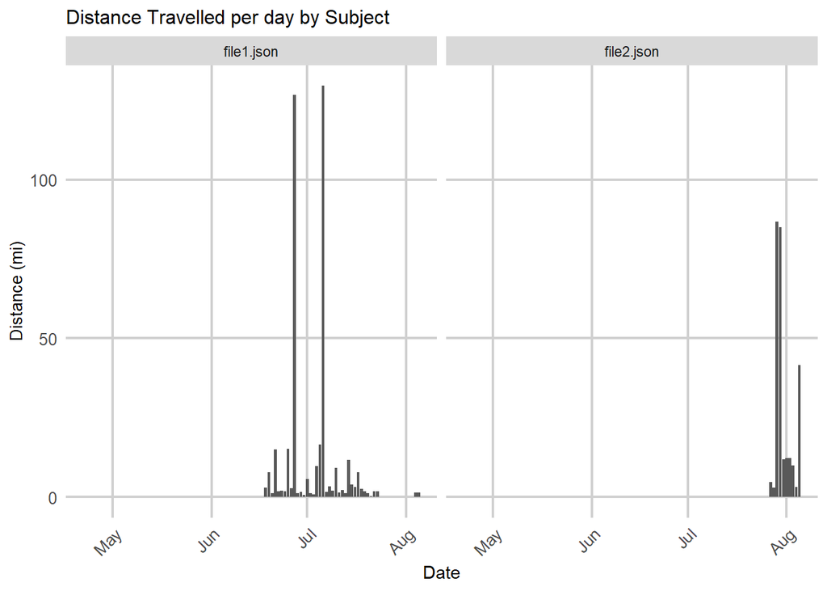

```r
ggplot(cleanData %>%
         mutate(intervalDaily = floor_date(ymd_hms(datetime), unit = "1 day")) %>%
         group_by(intervalDaily, filename)%>%
         summarize(total_lagDist_mi = sum(lagDist_ft, na.rm = TRUE) / 5280))+
  geom_bar(aes(x = intervalDaily, y = total_lagDist_mi), stat = "identity")+
  facet_wrap(~filename)+
  labs(
        title = "Distance Travelled per day by Subject",
        y = "Distance (mi)",
        x = "Date")+
  plotTheme
```

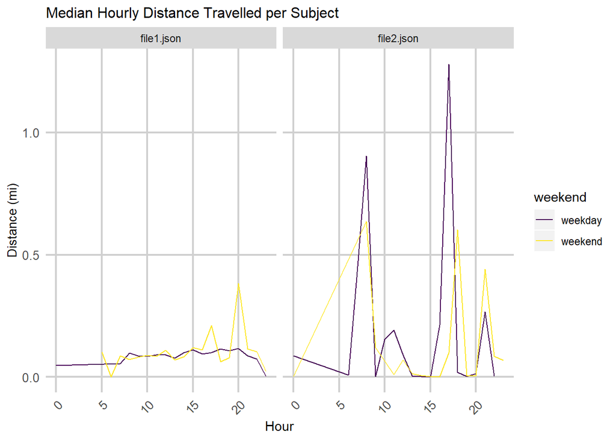

```r
ggplot(cleanData %>%
         mutate(interval60 = floor_date(ymd_hms(datetime), unit = "hour"),
                hour = hour(datetime),
         week = week(interval60),
         dotw = wday(interval60),
         weekend = ifelse(dotw %in% c(6, 7), "weekend", "weekday")) %>%
         group_by(weekend, hour, filename)%>%
         summarize(total_lagDist_mi = median(lagDist_ft, na.rm = TRUE) / 5280))+
  geom_line(aes(x = hour, y = total_lagDist_mi, color = weekend))+
  scale_color_viridis_d()+
  facet_wrap(~filename)+
  labs(
        title = "Median Hourly Distance Travelled per Subject",
        y = "Distance (mi)",
        x = "Hour")+
  plotTheme
```

## 5.4. Time - Space Sampling Rates

We can examine the relationship between distance travelled and sampling time. The median sampling time is something around four minutes

```r
quantile(cleanData$lagTime, na.rm = TRUE)
```

```
## Time differences in secs
##           0%          25%          50%          75%         100%
##       1.0010     161.8672     263.0050     748.7730 4898372.2460
```

So we want to remove some outliers to examine this relationship more closely.

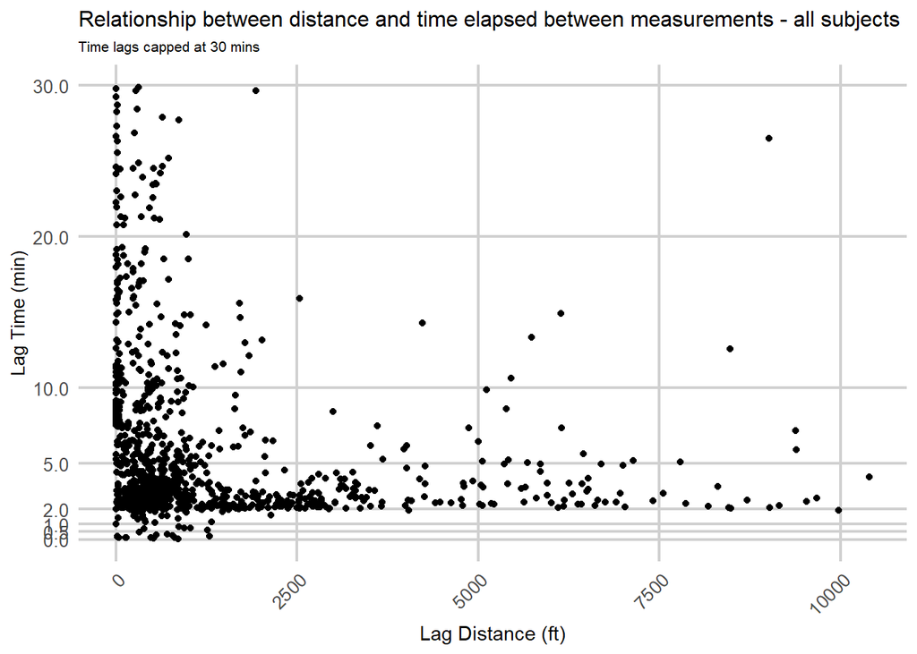

```r
ggplot(data = cleanData %>%
         filter(lagDist_ft < (5280*2), # distance of less than apx 2 mi
                abs((lagTime)/60) < 30) )+ # less than 15 min lag
  geom_point(aes(x= lagDist_ft, y = abs(as.numeric(lagTime)/60)))+
  #geom_smooth(aes(x= lagDist_ft, y = abs(as.numeric(lagTime)/60)),
  #            method = "loess", se = FALSE)+
  scale_y_continuous(breaks=c(0, 0.5, 1, 2, 5, 10, 20, 30))+
  labs(
    title = "Relationship between distance and time elapsed between measurements - all subjects",
    subtitle = "Time lags capped at 30 mins",
    y = "Lag Time (min)",
    x = "Lag Distance (ft)")+
  plotTheme
```

This plot can be run for just one subject by subsetting using an additional argument in the `filter` function applied to `cleanData` in the first chunk of `ggplot2` code like so:

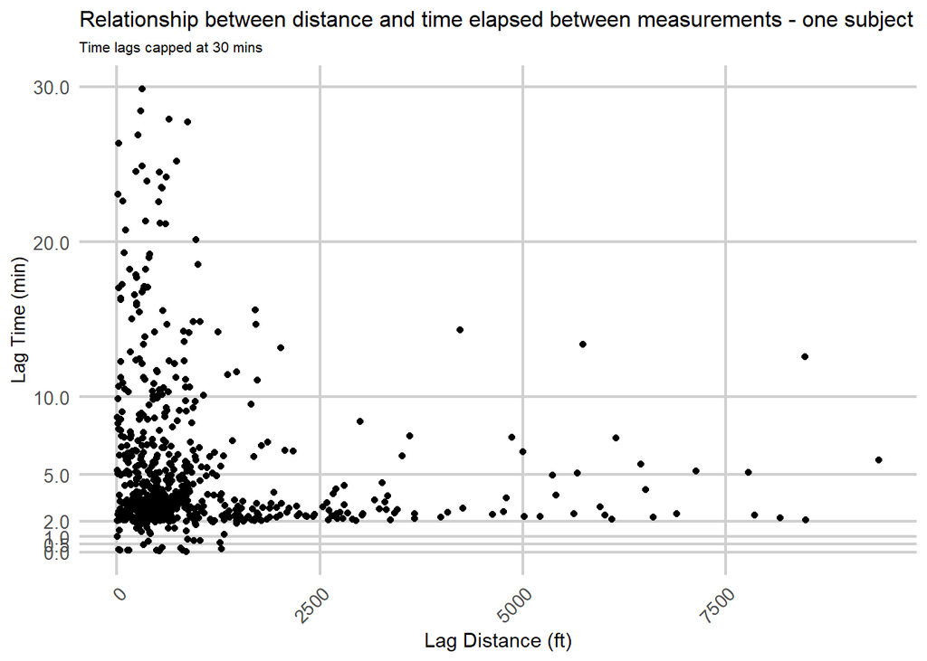

```r
ggplot(data = cleanData %>%
         filter(filename == "file1.json",
                lagDist_ft < (5280*2), # distance of less than apx 2 mi
                #lagDist > 0.001,
                abs((lagTime)/60) < 30) )+ # less than 15 min lag
  geom_point(aes(x= lagDist_ft, y = abs(as.numeric(lagTime)/60)))+
  #geom_smooth(aes(x= lagDist_ft, y = abs(as.numeric(lagTime)/60)),
  #            method = "loess", se = FALSE)+
  scale_y_continuous(breaks=c(0, 0.5, 1, 2, 5, 10, 20, 30))+
  labs(
    title = "Relationship between distance and time elapsed between measurements - one subject",
    subtitle = "Time lags capped at 30 mins",
    y = "Lag Time (min)",
    x = "Lag Distance (ft)")+
  plotTheme
```

This plot can also be facetted by `filename` in order to view multiple subjects alongside one another.

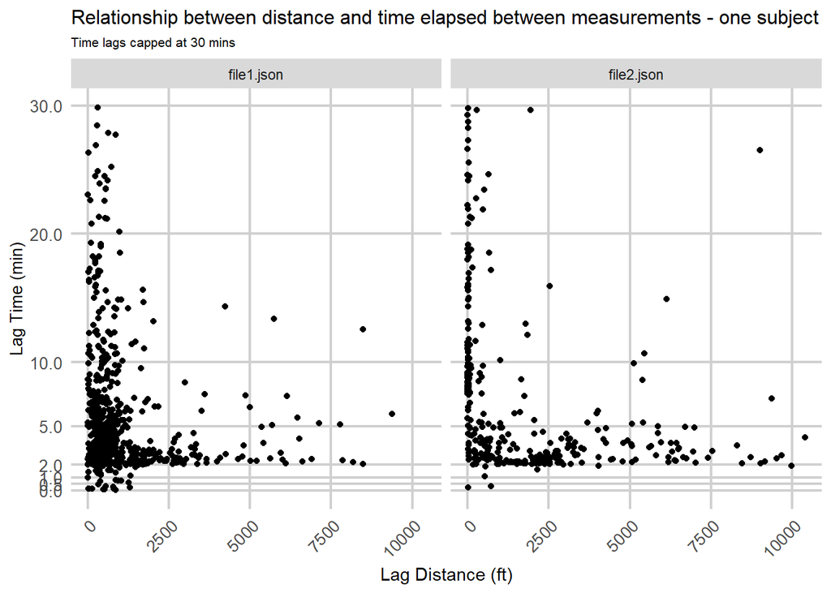

```r
ggplot(data = cleanData %>%
         filter(lagDist_ft < (5280*2), # distance of less than apx 2 mi
                #lagDist > 0.001,
                abs((lagTime)/60) < 30) )+ # less than 15 min lag
  geom_point(aes(x= lagDist_ft, y = abs(as.numeric(lagTime)/60)))+
  #geom_smooth(aes(x= lagDist_ft, y = abs(as.numeric(lagTime)/60)),
  #            method = "loess", se = FALSE)+
  scale_y_continuous(breaks=c(0, 0.5, 1, 2, 5, 10, 20, 30))+
  labs(
    title = "Relationship between distance and time elapsed between measurements - one subject",
    subtitle = "Time lags capped at 30 mins",
    y = "Lag Time (min)",
    x = "Lag Distance (ft)")+
  facet_wrap(~filename)+
  plotTheme
```

## 5.5. Distributions of Time-Space Lags

Do the distributions of sampling time and distance differ from subject to subject? It would appear so.

We should also be aware of the outliers in our distance lag observations

```r
quantile(cleanData$lagDist_ft, na.rm = TRUE)
```

```
##          0%         25%         50%         75%        100%
##      0.0000    236.8784    519.2272   1086.3202 665809.4852
```

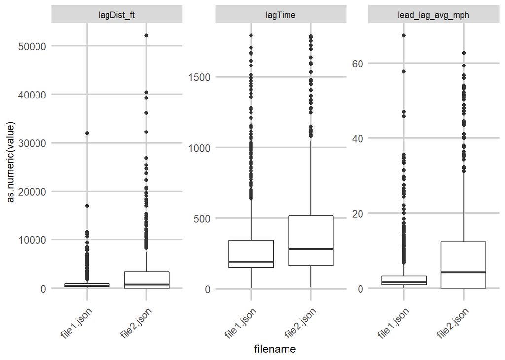

```r
ggplot(cleanData %>%
         ungroup() %>%
         filter(is.na(lagTime) == FALSE & is.na(lagDist_ft) == FALSE) %>%
         filter(abs((lagTime)/60) < 30,
                lagDist_ft < 100000,
                lead_lag_avg_mph <100) %>%
         as.data.frame() %>%
         select(filename, lagTime, lagDist_ft, lead_lag_avg_mph ) %>%
         gather(-filename, value = "value", key = "variable"))+
  geom_boxplot(aes(y = as.numeric(value), x = filename))+
  facet_wrap(~variable, scales = "free")+
  plotTheme
```

We can explore the relationship between `lead_lag_avg_mph` and measured velocity. Notice that there are numerous NA observations that must be removed for this plot to render - this is because lag and lead calculation necessarily introduces NA for calculations for which there is no lag or lead, and because the original velocity measurements are often NA because of measurement error.

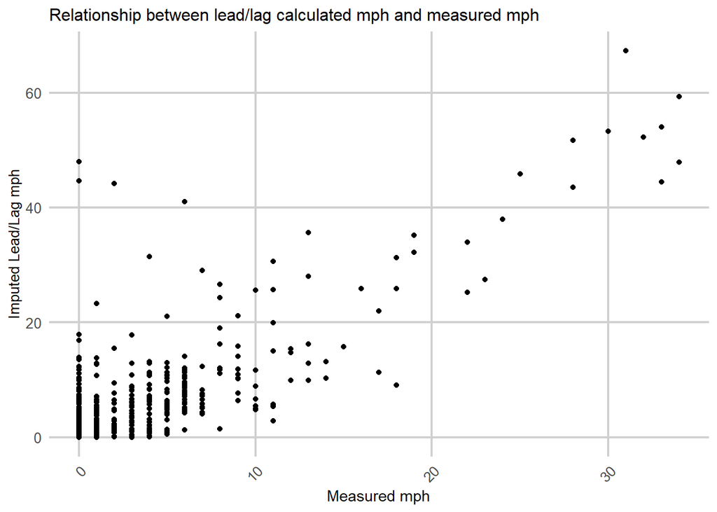

```r
ggplot()+
  geom_point(data = cleanData %>%
               filter(lead_lag_avg_mph<100),
             aes(locations.velocity, lead_lag_avg_mph))+
    labs(
    title = "Relationship between lead/lag calculated mph and measured mph",
    y = "Imputed Lead/Lag mph",
    x = "Measured mph")+
  plotTheme
```

# 6. Addition of Census Tract Info

Census spatial data can be drawn from the Census Bureau’s API and joined to our geoscanning observations using a point-in-polygon join. Each point will then be attached to a census geography, and this geography can be joined, via unique ID known as GEOID, to economic and demographic information from the US Census.

This section describes the process of calling the Census API using the `tidycensus` package and conducting the spatial join. It also describes the process by which one can call variables from the decennial census and the American Community Survey (ACS), with or without spatial information.

You can learn about the use of `tidycensus` ‘https://walkerke.github.io/tidycensus/articles/basic-usage.html’.

## 6.1. Load Census Variable Information

We can download libraries of census variable codes for the ACS (e.g. `acs5`) or for specific sheets for the decennial census (e.g. `sf1`) as data frames which we can `View` and sort through in order to find the variables relevant for use.

```r
v17 <- load_variables(2017, "acs5", cache = TRUE)

View(v17)
```

## 6.2. Call Census API for Spatial Data

We are going to need to understand the spatial extent of our study area in order to load the Census tracts we will need to join all of our points. Whether the travels of the subjects outside the retailer study area are of interest would necessitate a certain routine to grab the nation’s entire census database of counties in order to find every location where a spatial join would be necessary.

For now, we will merely grab data in our demonstration study states which we have saved in the vector that we sent to `tigris` to retrieve county shapefiles earlier. If we deem the data to be too expansive, we can reduce it to just the counties in our `countiesList` using a `left_join` - the county GEOID is the first five digits of the tract GEOID. If we want more data, we can assemble the entire country, but as spatial data, this may be ungainly.

Be aware that Census Tracts will be redrawn based on the results of the 2020 Census, and some choices will need to be made with respect to appropriate geometries and time periods of study.

We can specify the census variables we’d like to attach - in this case we will simply use `B01003_001` (total population) and `B19013_001`. We create a vector called `myACS_Vars` to store these variables. The call will return data appended with an E for “Estimate” or an “M” for “Margin of Error.”

```r
myACS_Vars <- c("B01003_001", "B19013_001")
```

Here we do a `get_acs` call, but a `get_decennial` call, using different variable names, would produce something comparable for a decennial census year.

The result is an `sf` object with geometries attached. We set the projection to `crs = 4326` aka WGS84 so that it is mutually intelligible with our point data. If we are using a large geographic scale, a geographic coordinate system like WGS84 will be better suited than a projected coordinate system.

If this call is made with the `geometry` argument set to `FALSE`, only tabular data will be imported, and the data will be formatted as a tibble or data frame (e.g. a flat file with no geometry).

```r
PA_NJ_DE_tracts <-
    get_acs(geography = "tract",
            variables = myACS_Vars,
            year = 2017,
            state = c("PA", "NJ", "DE"),
            geometry = TRUE,
            output = "wide") %>%
  rename(Total_Pop_est =  B01003_001E,
         Total_Pop_err = B01003_001M,
         Med_Inc_est = B19013_001E,
         Med_Inc_err = B19013_001M) %>%
  st_transform(crs = 4326)
```

## 6.3. Join Observations To Census Data

We can conduct a point-in-polygon spatial join of our geoscanning observations to our 2010 census tract geograhies. Each observation will now be associated with the tract in which it is located.

In this code block, we are imparting the relevant tract ID only by using the `select` function and keeping only the `GEOID` and `NAME` identifiers. The idea is that you can join the data to census information at any point using a tabular join by one of these unique IDs. One may keep any and all census variables if you wish.

Note that both data sources need to be in the same coordinate system, in this case `crs=4326` aka WGS84 aka “Web Mercator”. This coordinate system is particularly suitable for large geographic areas but uses a linear unit of decmial degrees, and should not be used for spatial analysis where straight line distances or areas are being measured.

```r
cleanData_join_census <- st_join(cleanData %>%
                                    st_transform(crs = 4326),
                             PA_NJ_DE_tracts %>%
                               select(GEOID, NAME) %>%
                               st_transform(crs = 4326),
                             join = st_intersects,
                             left = TRUE)
```

## 6.4. Summarize and Map Observations by Tract

The data can now be easily summarized and mapped by Census geographies.

Here we will just examine a map of Philadelphia county by subject - but this approach can be used to subset any geography for mapping.

We create a “bounding box” to set the limits of the mapping environment, in this case called ‘philaBox’.

We create a summary of observations by tract. This is done inside of a ggplot call’s `geom_sf` geometry call so as not to create a datframe in our environment. Mainly this is a matter of taste and housekeeping for the data environment. But this can be done outside of a ggplot call if desired- one can create a data frame in order to summarize in tabular form or analyze further.

We summarize our data by Census GEOID and subject using the `group_by` and `summarize` functions in sequence. Note that we coerce `cleanData` to a data frame prior to doing this. The `geometry` column of an `sf` object is resistent to being discarded as part of a summarization.

We can then join our summary to the `sf` object consisting of census tract geographies. We send our summary to the “right” side of a `left_join` with our larger tract shapefile. All of the tracts on the “left” are kept - so that we keep all of the tracts with zero observations.

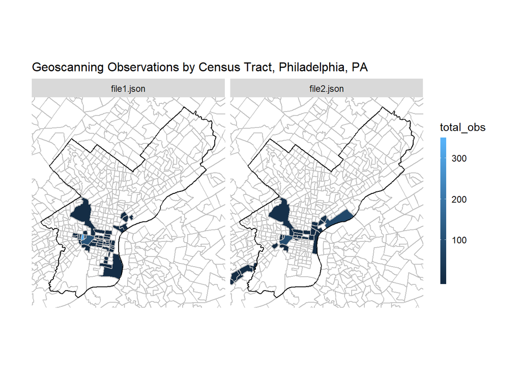

```r
philaBox <- st_bbox(counties %>%
                      filter(NAME == "Philadelphia"))

ggplot()+
  geom_sf(data = PA_NJ_DE_tracts, color = "grey", fill = "transparent")+
  geom_sf(data = cleanData_join_census %>%
            as.data.frame() %>%
            group_by(GEOID, filename) %>%
            summarize(total_obs = n()) %>%
            left_join(PA_NJ_DE_tracts, .) %>%
            filter(is.na(filename) == FALSE),
          aes(fill = total_obs),
          color = "grey")+
  scale_color_viridis_d()+
  geom_sf(data = counties %>%
                      filter(NAME == "Philadelphia"),
          fill = "transparent", color = "black")+
  facet_wrap(~filename)+
  xlim(philaBox$xmin, philaBox$xmax)+
  ylim(philaBox$ymin, philaBox$ymax)+
  labs(
    title = "Geoscanning Observations by Census Tract, Philadelphia, PA")+
  mapTheme
```

## 6.5. Summarize Observations By Tract Characteristics and by Time

We can also tabulate assorted statistics per tract and relate them to underlying census information.

Here are some examples. Note that in some of the following code, rather than including data manipulation within a ggplot call, we `pipe` manipulations of `cleanData_join_census` right into a `ggplot` call using the `%>%` operator.

First example:

We can calculate the frequency of observation by census tract and relate that to the only demographic variable we have grabbed so far, Median Household Income.

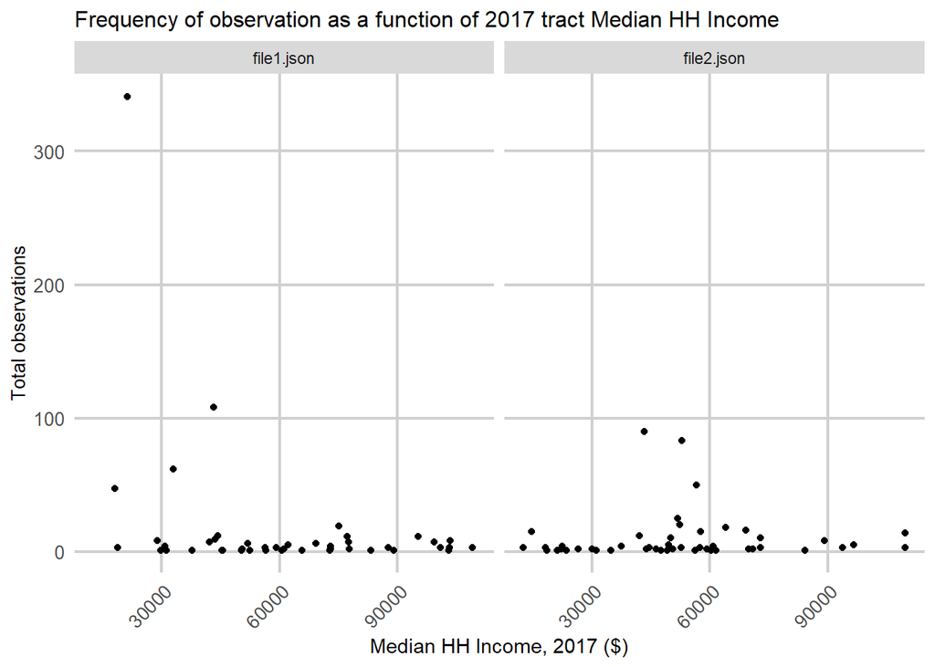

```r
cleanData_join_census %>%
  as.data.frame() %>%
  group_by(GEOID, filename) %>%
     summarize(total_obs = n()) %>%
  left_join(PA_NJ_DE_tracts, .) %>%
     filter(is.na(filename) == FALSE) %>%
  ggplot()+
  geom_point(aes(y = total_obs, x = Med_Inc_est)) +
  facet_wrap(~filename)+
  labs(
    title = "Frequency of observation as a function of 2017 tract Median HH Income",
    y = "Total observations",
    x = "Median HH Income, 2017 ($)"
    )+
  plotTheme
```

We can calculate the median speed by census tract and relate that to income - how quickly are our subjects, on average, moving through areas of higher or lower poverty?

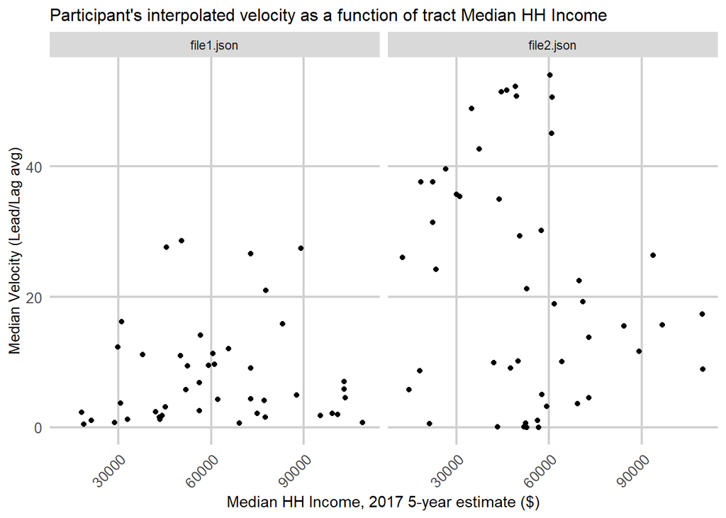

```r
cleanData_join_census %>%
  as.data.frame() %>%
  select(-geometry) %>%
  group_by(GEOID, filename) %>%
     summarize(median_speed = median(lead_lag_avg_mph, na.rm = TRUE)) %>%
  left_join(., PA_NJ_DE_tracts) %>%
     filter(is.na(filename) == FALSE) %>%
  ggplot()+
  geom_point(aes(y = median_speed, x = Med_Inc_est)) +
  facet_wrap(~filename)+
  labs(
    title = "Participant's interpolated velocity as a function of tract Median HH Income",
    y = "Median Velocity (Lead/Lag avg)",
    x = "Median HH Income, 2017 5-year estimate ($)"
    )+
  plotTheme
```

We can look at a weekday vs weekend breakdown by subject - in this case let’s just examine the top 20 tracts in an individual’s data set. We do this by taking our `cleandata_join_census` and extracting time information so as to understand which day of the week each observation took place, grouping by time of the week and tract and summarizing. We keep only the top 20 tracts by count for each subject.

As an alternative to chloropleth maps of polygons, we represent them using graduated points by extracting the centroids. As such, we mutate to create lat/lon information by extracting a centroid value, and we create a geom_point upon which we place our graduated point, symboogized by `total_obs`.

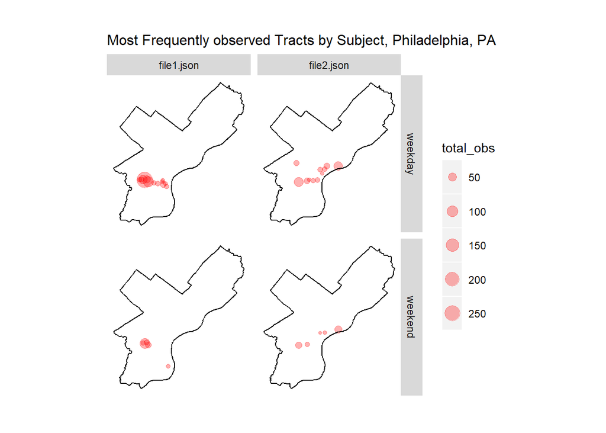

```r
ggplot()+
  geom_point(data = cleanData_join_census %>%
            as.data.frame() %>%
            select(-geometry)%>%
    mutate(interval60 = floor_date(ymd_hms(datetime), unit = "hour"),
           hour = hour(datetime),
           week = week(interval60),
           dotw = wday(interval60),
           weekend = ifelse(dotw %in% c(6, 7), "weekend", "weekday")) %>%
    group_by(weekend, filename, GEOID)%>%
    summarize(total_obs = n()) %>%
      group_by(filename) %>%
      top_n(20) %>%
      left_join(PA_NJ_DE_tracts, .) %>%
    filter(is.na(filename) == FALSE) %>%
      mutate(lon=map_dbl(geometry, ~st_centroid(.x)[[1]]),
                       lat=map_dbl(geometry, ~st_centroid(.x)[[2]])),
aes(x= lon, y = lat, size = total_obs),
          color = "red", fill = "white", alpha = 0.3)+
  scale_color_viridis_d()+
  geom_sf(data = counties %>%
                      filter(NAME == "Philadelphia"),
          fill = "transparent", color = "black")+
  facet_grid(weekend~filename)+
  xlim(philaBox$xmin, philaBox$xmax)+
  ylim(philaBox$ymin, philaBox$ymax)+
  labs(
    title = "Most Frequently observed Tracts by Subject, Philadelphia, PA")+
  mapTheme
```

# 7. Retailer Locations

Eventually, that data should replace that uploaded in the section below. As of this writing (November, 2019), variable names reflect the PA retailer database from November, 2018. These names and the data conventions of PA data have changed since then and will need to be updated in the code in order to accomodate new data.

Given the change in data conventions, it would be prudent to separate the procurement, cleaning, geocoding and coalesence of the retailer database into a standalone code work flow. The retailer database could then be loaded into the main code workflow whole cloth and this entire section could be skipped - instead going straight to the process of buffering and joining retailer information to geolocation information to infer exposure.

## 7.1. Set directory for loading retailer data

```r
retailer.directory ='//jove.design.upenn.edu/Dept-Shares/prax/01 Project Folders/2019_Annenberg_GeoScanning/inputData/RetailerMaps/RetailerMaps/'

setwd(retailer.directory)
```

## 7.2. Load Shapefile and Subset Relevant Data

We load our retailer data base using the `st_read` function in the `sf` package, and passing a handful of `` dplyr``filter `` commands to subset data according to a set of criteria. These criteria are:

-Remove non PA retailers and retailers with mis-identified counties as being PA -Remove vending machine license types -Keep only observations in counties from our study area `countyList`

These criteria can be changed depending on the parameters of the study.

```r
setwd(retailer.directory)

retailers <- st_read("PA/2018_11/rows_11/rows_11.shp") %>%
  filter(location_3 == "PA",
         county != "UNKNOWN/OUT OF STATE",
         license_ty != "Vending")%>%
  filter(as.character(county) %in% toupper(countyList))
```

```
## replacing null geometries with empty geometries
## Simple feature collection with 19395 features and 22 fields (with 1655 geometries empty)
## geometry type:  POINT
## dimension:      XY
## bbox:           xmin: -122.3861 ymin: 25.80076 xmax: -71.34784 ymax: 43.18126
## epsg (SRID):    4326
## proj4string:    +proj=longlat +datum=WGS84 +no_defs
```

We can filter retailer data further to only include items in our study area. If using data for multiple states, this may need to be augmented.

## 7.3 Assess Missing Geometries

We expect some of these stores to be missing geometry information. How many of these are missing geometries (e.g. `TRUE` in the below query)?

```r
summary(is.na(retailers$computed_r))
```

```
##    Mode   FALSE    TRUE
## logical    6997     348
```

## 7.4. Fix Missing Geometries Through Geolocation

We can fix our missing geometries by using a third party geolocation service. This can be done in one of several ways - for many services there are fees to prevent abuse.

It’s advisable not to run this more than you have to - you may exceed the limits of a starter account. Even if this is not an issue, geocoder failures are not always predictable, and the API may have some issues when you least expect it, so best to save your workspace or output your retailer data to file when you’re done.

First we concatenate our location data to include number, street name, city, postal code etc. in one string that can be fed to the geocoding API, We do this using the `unite` function from the `dplyr` package to create a field called `address_full` from our location fields, separated by a comma (the `sep` argument).

We subset the observations lacking a location (indicated in this data by `computed_1` and other administrative indicators of geocoding, but might be different with other data) and set them aside as a data set called `to_geocode`.

```r
retailers <- retailers %>%
  mutate(location_1 = as.character(location_1),
         location_2 = as.character(location_2),
         location_3 = as.character(location_3),
         postal_cod = as.character(postal_cod)) %>%
  unite(., "address_full", c("location_1",
                             "location_2",
                             "location_3",
                             "postal_cod"),
        sep = ", ")

to_geocode <- retailers %>%
  filter(is.na(computed_1) == TRUE)
```

Until recently there were several geocoders of reasonable quality that were available for free, especially for small runs. To deter developers from making endless API calls, high quality services such as the Google geodocidng API are available only for a fee.

Fortunately, this is not a geocoding-intensive project, with several hundred observations requiring one-time geocoding. The `ggmap` package allows for simple geocoding by address in R, with the google API as one of the available extensions.

I have registered an API key, and so can you, which gets you a 300 dollar starting credit. A thousand requests cost 5 dollars.

MY API KEY is in this code - if you are running this codebase, consult with me, or get your own, or I will come calling when I get my credit card statement!

If you want to do an alternative, go to the Texas A&M geocoder for one time service.

Information about using the ggmap package and the google API can be found at the [‘r-bloggers’](https://www.r-bloggers.com/geocoding-with-ggmap-and-the-google-api/) site. You can follow that link to get your own account started.

Begin by registering your key with the `ggmap` function `register_google`

```r
register_google(key = "AIzaSyDGhyb11VDr6nuakmilEF4BmmNY_AmhKrw")
```

The `geocode` function takes a vector argument of addresses and a geocoder source (in this case “google”) and returns a pair of vectors with latitude and longitude.

To re-iterate, you do not want to run geocoding tasks more than you have to - if you are running and re-running the code-base with new geo-location data or new analytics, you don’t need to re-run the geolocation. Instead, when you run geocoding script on what you think will be your final store data, write it out to file, comment out the code in the codebase and run an `st_read` or `read.csv` other upload function to bring the data into your environment depending on how you decide to save it to file.

If re-running this markdown, leave this chunk as `eval = FALSE` so as not to inadvertantly re-run the geocoder and bill time. Instead, run the chunk below which loads the data output in this chunk.

```r
retailers_geocoded <- geocode(to_geocode$address_full, source =  "google")
write.csv(retailers_geocoded, "//jove.design.upenn.edu/Dept-Shares/prax/01 Project Folders/2019_Annenberg_GeoScanning/dataOutputs/retailers_geocoded_10_14_19.csv")
```

```r
retailers_geocoded <- read.csv("//jove.design.upenn.edu/Dept-Shares/prax/01 Project Folders/2019_Annenberg_GeoScanning/dataOutputs/retailers_geocoded_10_14_19.csv")
```

We can add our geocoded data to our original data set, but we still have a few NA values. Some points may need to be manually adjusted because their location string is something that standard geocoders cannot handle (e.g. NE Corner of Street A and B).

The `sf` package can’t turn something with NA data into spatial data, so we must either exclude these NA points or iterate the geocoding and fix un-geocodable observations until we have successfully assigned lat/lon values to all of our points. To proceed to buffering and other geoprocessing, we will have to decide what to do about these NA observations. Until then, we will extract lat/lon values and move into a data frame format for a little bit.

To recombine our `retailers_geocoded` with our original data set, we follow these steps:

-We take our retailers, filter for those observations which we needed go geocode (e.g. `is.na(computed_1) == FALSE)`, leaving our original data set for which we have lat/lon.

-We `mutate` to create new `lat` and `lon` columns to which we extract the values of the coordinates in our `geometry` column

-We convert our data type to data frame and remove the geometry by an anti-`select`

-This first set of operations produces a data set whose rows we bind using `rbind` to the following data-

-We take our `to_geocode` object, turn it to a dataframe and remove the geometry, and bind its columns (`cbind`) to our `retailers_geocoded` data which consists only of lat/lon observations indexed at the same length as the `to_geocode` object that we sent out to our geocoding API in the previous steps.

This produces (essentially) a reconstitution of our original retailers data set but with far more lat/lon info.

```r
original_plus_geocoded <- rbind(retailers %>%
                filter(is.na(computed_1) == FALSE) %>%
                mutate(lon=map_dbl(geometry, ~st_centroid(.x)[[1]]),
                       lat=map_dbl(geometry, ~st_centroid(.x)[[2]]))%>%
                  as.data.frame() %>%
                  select(-geometry),
      cbind(to_geocode %>%
              as.data.frame() %>%
              select(-c(geometry)),
            retailers_geocoded %>%
              select(-X)))
```

As mentioned previously, we can’t turn NA lat/lon data into `sf` observations.

For the time being, let’s exclude the NA values and convert our data frame to an sf object.

```r
original_plus_geocoded <- original_plus_geocoded %>%
  filter(is.na(lat) == FALSE & is.na(lon) == FALSE) %>%
  st_as_sf(., coords = c("lon", "lat"), crs = 4326)
```

# 8. Buffer Retailer Locations

In order to do geoprocessing operations like buffering, we need to reproject our data from a geographic coordinate system projected in decimal degrees, like WGS84, to something projected in a linear unit such as feet. For our study area, the ideal projection is PA State Plane South, (crs = 2272).

We `st_transform` our `original_plus_geocoded` sf object to `crs = 2272` and `st_buffer` it using a distance of 100 feet to create a new polygon sf object called `retailers_buffer`, which contains all the same tabular information as our original store data.

```r
retailers_buffer <- original_plus_geocoded %>%
  st_transform(crs = 2272) %>%
  st_buffer(., 100) # the number here is the buffer size in feet
```

We can check to see if any features are invalid.

```r
retailers_buffer %>%
  mutate(valid_shape = st_is_valid(.)) %>%
  filter(is.na(valid_shape) == TRUE)
```

```
## Simple feature collection with 0 features and 20 fields
## bbox:           xmin: NA ymin: NA xmax: NA ymax: NA
## epsg (SRID):    2272
## proj4string:    +proj=lcc +lat_1=40.96666666666667 +lat_2=39.93333333333333 +lat_0=39.33333333333334 +lon_0=-77.75 +x_0=600000 +y_0=0 +ellps=GRS80 +towgs84=0,0,0,0,0,0,0 +units=us-ft +no_defs
##  [1] computed_r   expiration   address_full version      trade_name
##  [6] created_at   computed_1   computed_2   country      county
## [11] cartodb_id   computed_3   computed_4   legal_name   updated_at
## [16] account      id           location_4   license_ty   valid_shape
## [21] geometry
## <0 rows> (or 0-length row.names)
```

# 9. Spatial Join

In order to join our geo-location points and our polygons, the points `cleanData` need to be projected as the same crs as `retailers_buffer`, so one or the other must be reprojected using `st_transform`.

The `st_intersects` function is called within the `st_join` function - specified as the specific type of spatial join we wish to execute. We are making a left join `left = TRUE` so that we keep all of our geolocation observations while joining the information related to a buffered area which they intersect. We then clean out some extraneous information about the stores using the `select` command.

The resulting sf object, `cleanData_join_buffers` will be the data set which will allow us to measure “exposure” to point-of-sale tobacco sites, ads etc.,

```r
cleanData_join_buffers <- st_join(cleanData %>%
                                    st_transform(crs = 4326),
                             retailers_buffer %>%
                               st_transform(crs = 4326),
                             join = st_intersects,
                             left = TRUE) %>%
  select(-c(computed_r, version, computed_1, computed_2, computed_3))
```

```
## although coordinates are longitude/latitude, st_intersects assumes that they are planar
```

# 10. Measure Exposure

To measure exposure, we filter out observations which lack an `id` for a joined retailer, and group observations by `month`, `year`, `day`, `filename` (eg subject), `trade_name` and `id` (eg retailer). We could be even more specific if we believe there are likely to be multiple subject-retailer exposures in a given day, grouping further by hour.

Most of these exposure incidents do not have any residence time associated with them - e.g. just one point in a buffer. We create several variables which allow us to further determine whether or not an interscting point-in-polygon incident is actually an exposure. By carrying along our inputed and measured speed variables and time lag variables we can figure out if there was a passby at high speed or actually some lingering.

The variables we create are as follows:

`duration_seconds` - total exposure duration of grouped points at one retailer on one day. Equals zero if just one point.

`max_lead_lag_mph` - for all grouped points at one retailer on one day, the max value of imputed lead/lag velocity.

`range_lead_lag_mph` - For all grouped points at one retailer on one day, the range of imputed lead/lag velocity.

`max_measured_mph` - For all grouped points at one retailer on one day, the max value of measured lead/lag velocity. This value is likely to be `NA` because of measurement error.

`three_time_lags_sec` - For all grouped points at one retailer on one day, the mean value of each observation’s averaged three distance lags.

`license_created` - The date associated with the creation/renewal of the retailer license in the data set (be careful - the license database is periodically updated, and may have new renewal dates that post-date exposures to the same location under a previous license).

`license_expiration` - Expiration date of retailer license

`license_active` - A variable which indicates whether the license was active at the time of the exposure measurement.

Checking for active licensure may involve creating a separate input which tracks the initial creation and ultimate expirations of retailers in the data set because license databases do not seem to overwrite each year.

```r
exposure_durations <- cleanData_join_buffers %>%
            filter(is.na(id) == FALSE) %>%
            mutate(month = month(datetime),
                   year = year(datetime),
                   day = day(datetime)) %>%
            group_by(month, year, day, filename, trade_name, id) %>%
            summarize(duration_seconds = max(datetime) - min(datetime),
                      max_lead_lag_mph = max(lead_lag_avg_mph),
                      range_lead_lag_mph = max(lead_lag_avg_mph) - min(lead_lag_avg_mph),
                      max_measured_mph = max(locations.velocity),
                      three_time_lags_sec = mean(mean_3_lagDist_ft),
                      license_created = min(created_at),
                      license_expiration = max(expiration),
                      min_datetime = min(datetime),
                      max_datetime = max(datetime)) %>%
  mutate(license_active = ifelse(min_datetime < as.POSIXct(license_expiration) & max_datetime < as.POSIXct(license_expiration), "ACTIVE", "INACTIVE"))
```

# 11. Spatialize Exposure Risk Using a Fishnet

We can create a “surface” which reflects some measure of the underlying exposure conditions. This can be done either by a rule-based set of assumptions based on independent variables only (e.g. each cell within a certain distance of a store has an exposure score to one or more stores). Alternately, the surface could be the product of the observed relationship between exposure and craving such that it can be based on the actual outcomes to be expected.

## 11.1. Create the fishnet

We create a polygon “fishnet” to the extent of our study area (e.g. our Counties), which has been reprojected to a NAD 83 PA State FIPS CRS with a linear unit of feet. This “fishnet” is basically a polygon version of a raster layer, the resolution corresponds to the `cellsize` parameter, which can be altered depending on the scale deemed appropriate.

In this example code block, we merely use the county of Philadelphia.

```r
fishnet <- st_make_grid(counties %>%
            filter(NAME == 'Philadelphia')%>%
            st_transform(crs = 3365),
            cellsize = 1000) %>% #size in feet
  st_sf() %>%
  st_transform(crs = 4326)
```

We can crop our fishnet by our study area (again, for demo purposes, just the county of Philadelphia) and apply a `uniqueID` to each cell. We can also create a lat/lon centroid point for each cell using the `st_centroid` function. This will come in handy later.

```r
fishnet <- fishnet[counties %>% filter(NAME == "Philadelphia"),] %>%
  mutate(uniqueID = rownames(.)) %>%
  select(uniqueID) %>%
  mutate(lon=map_dbl(geometry, ~st_centroid(.x)[[1]]),
         lat=map_dbl(geometry, ~st_centroid(.x)[[2]]))
```

## 11.2. Join and summarize retailer density by grid cell

For each grid cell we see how frequently the 100 foot buffers created by our retailer locations intersect our cells. We then bind this information back to our fishnet grid cells.

Alternately, a nearest-neighbor distance approach could be utilized to find the mean straight-line distance to the nearest k retailers for each cell centroid.

This surface represents a sort of rule-based risk surface derived from some assumptions about the effect of exposure, but could be replaced with predictions of risk based on experimental results about the observed relationship between exposure and other predictors and subject behavior.

```r
fishnet_join_buffers <- st_join(fishnet,
                             retailers_buffer %>%
                               st_transform(crs = 4326),
                             join = st_intersects,
                             left = TRUE) %>%
  select(uniqueID, address_full, trade_name) %>%
  group_by(uniqueID) %>%
  tally() %>%
  mutate(n = ifelse(n == 1, 0, n)) %>%
  rename(exposures_100ft = n) %>%
  as.data.frame() %>%
  select(-geometry) %>%
  left_join(fishnet, .)
```

As an additional visualization - let’s examine the density of retailers. We can create a basemap later for visualizing our study area that will allow for some better reader comprehension of the geography.

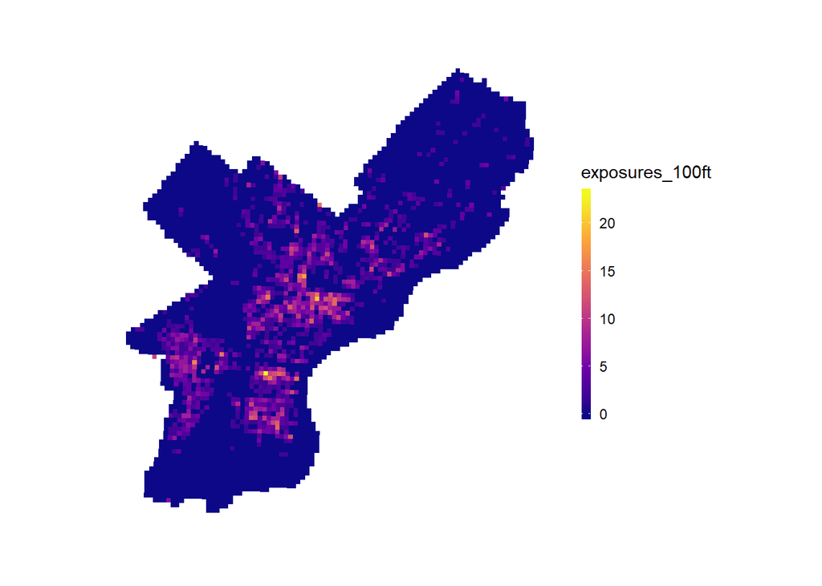

```r
ggplot()+
  geom_sf(data = fishnet_join_buffers,
          aes(fill = exposures_100ft),
          color = "transparent") +
  scale_fill_viridis_c(option = "plasma")+
  mapTheme
```

We can also overlay our subject observations, here cropped to the bounding box of the city, but they can be spatially clipped to the precise geography as well:

```
## although coordinates are longitude/latitude, st_intersection assumes that they are planar
```

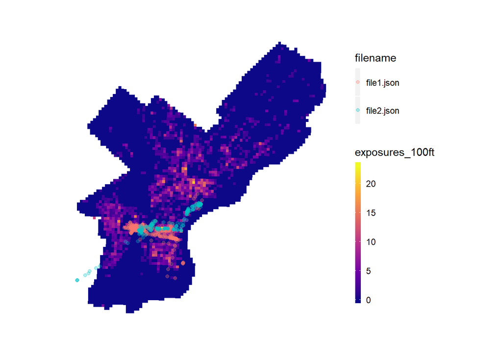

```r
ggplot()+
  geom_sf(data = fishnet_join_buffers,
          aes(fill = exposures_100ft),
          color = "transparent") +
  scale_fill_viridis_c(option = "plasma")+
  geom_point(data = cleanData %>%
               #filter(filename == "file1.json") %>%
               st_crop(., fishnet_join_buffers)%>%
               mutate(lon=map_dbl(geometry, ~st_centroid(.x)[[1]]),
                      lat=map_dbl(geometry, ~st_centroid(.x)[[2]])),
             aes(x = lon, y = lat, color = filename), alpha = 0.3)+
  mapTheme
```

# 12. Project status

## 12.1. Phase 3

Basic outline of data intake, retailer geolocation and buffering, spatial joining and summary is complete. Phase 4 contains the general scope for the data wrangling tasks associated with scaling the code to a “production” version and expanding the geographic scale and number of subjects described in this document. This involves the creation and managment of longitudinal, multi-state retailer databases, additional data visualization and description, data structure routines to accomodate experimental designs and more.

## 12.2. Phase 4

**Data wrangling:**

- Coalesce multi-state longitudinal retailer information with a start and end date for retailer licensure and unique ID (for NJ data, which lacks this). Multi-state coalescence and multi-temporal coalescence will require merging data standards. This will likely need to be done on an ongoing basis as retailer info is continually updated. Create logic to cross check exposures against this date range. Based on data addition / loss, create geocoding routine for new data. Integrate the use of SODA API for regular calls to the PA database. (See Appendix 2 of this document)
- Geocode the full retailer dataset including all of NJ and PA observations without spatial information, including potential data research into un-geocodable locations. This may involve updating geocoding routines to use `tidygeocoder` and not the Google Maps API or investing in a Google developer account for the project. Retailer-by-retailer research may be necessary. See Appendix 2 for more information.
- Update the exposure point-in-polygon join to include a check for whether the observation happened within a time window where the license was active.
- Add CVS information to spatial database
- Using `tidycensus` API package, add relevant census variables to join to geotracking observations as dictated by research needs.
- Brad: ‘user to supply discrete time bins (unique to each subject) of 1-2 hours and get summary statistics (e.g., exposure duration, average gini by census tract) for each bin’

**Data Management:**

- Create a file structure and sub-routines for storing data and cleaning participant data on intake.
- Create a management routine and separate code workflow for coalescing and maintaining retailer database. (See Appendix 2 of this document)
- Create conventions to move data storage to “PennBox” using `boxr`.
- Create and maintain metadata and a data library associated with ongoing research and documentation associated with a file structure and data standards.
- Get timeframe for each subject or group of subjects - create this as an input, each subject with a date range

**Project conceptualization and modeling:**

- Formalize quantitative notions of exposure and codify the logic in the code base
- Build data structures and variables necessary to support modeling process.
- Assess viability of first round of data collection in modeling context.
- Expand geographic scope to additional states and areas as specified by research needs.
- Explore analytical possibilities of the fishnet aka the “risk surface” including a predicted risk surface based on experimental results (most powerful) or known relationships drawn from research.

**Spatial interpolation:**

- Interpolate a route for each subject between known observations (if possible). Link this to the street network (difficult) or straight line tracts in between observations (a bit easier)

**App Development:**

- Create leaflet intake tool to allow subjects to identify their homes and “home store” (using R Shiny and operable on a desktop in a subject-researcher setting)

# 13. Appendix 1. - KML Loading

Previous versions of this code base used kml data. For reasons previously enumerated, JSON is preferrable. The functional but retired code base is below. It is designed to pull a list of kml files from a folder and transform them into a flat file.

## 13.1. Set Up Function Parameters

```r
file.directory ='//jove.design.upenn.edu/Dept-Shares/prax/01 Project Folders/2019_Annenberg_GeoScanning/inputData/Timeline/Timeline/AllData_T3'

setwd(file.directory)

file.name <- list.files(path=file.directory, pattern = "*.kml")
```

## 13.2. ReadKML function

This function parses the kml text to look for particular strings which correspond to the date, time and coordinate data we need to run our analysis. Because the kml exports we have chosen to use have assorted missing carriage returns in their bodies and other weird syntax problems, they do not run with standard drivers using `sf` in R or in ESRI software - hence the elaborate text parsing routine.

```r
ReadKML <- function(filename){
  kml.text <- readLines(filename)
  # Get strings with the word 'coord' in it
  coords <- kml.text[grep("<gx:coord>", kml.text)]
  datetime <- kml.text[grep("<when>", kml.text)]
  # Get the numbers out from coords
  coords <- data.frame(str_match(coords, "\t\t\t\t<gx:coord>(.*?)</gx:coord>")[,2])
  coords <- data.frame(str_split_fixed(coords[,1], " ", 3), stringsAsFactors = FALSE)
  coords <- data.frame(sapply(coords, as.numeric))
  names(coords) <- c("longitude", "latitude", "altitude")
  # process datetime
  datetime <- data.frame(str_match(datetime, "\t\t\t\t<when>(.*?)</when>")[,2],
                         stringsAsFactors = FALSE)
  datetime[,1] <- as.POSIXct(datetime[,1], format="%Y-%m-%dT%H:%M:%SZ")
  names(datetime) <- "datetime"
  id <- substr(filename, 1, nchar(filename)-4)
  # combine to a data frame
  data <- cbind(datetime, coords)
  data$id <- id

  return(data)
}
```

## 13.3. Run the Function

We loop through file names to run the text parsing routine for each file and subsequently `rbind` them - binding the rows together.

If you get an error that says “incomplete final line” - this means that the file itself doesn’t have a carriage return or “EOL” End of Line character. This can be added manually.

The output is called `gt.track`.

```r
gt.track <- NULL

for (i in file.name) {
  location <- ReadKML(i)
  gt.track <- rbind(gt.track, location)
}
```

# 14. Appendix 2 - Importing Retailer Data Using SODA API - IN PROGRESS

The following is a working outline for the coalesence and maintenance of multiple retailer databases on an ongoing basis. The data standards for NJ and PA differ, and the PA data standards have changed in the last year, and may change further still. This database can then be built into an augmented routine which date-checks exposure incidents against the date ranges of the relevant retailers. Ideally, there should be one master data base with a time component that can be compared to geoscanning observations.

**The retailer database will have the following characteristics:**

- Its own code base, perhaps, run separately from the geoscanning code - and called either as a function or with its output as an object (e.g. an sf object to be joined to geoscanning observations as needed)
- A date range for the earliest and latest observations of the retailer within the data set - this will allow for cross-checking observations to determine if exposure took place while license was active
- A set of data standards (unique ID, minimal geo-data and time characteristics) that will allow for multiple states with disparate standards to exist in one database
- A routine for geocoding so as to preserve “tokens” with geocoding services, and selection of a standard geocoder (perhaps with a linked paid developer account) that can be used

**The basic workflow for working with retailer information will be as follows:**

For PA data -

- On an ongoing basis, read in json from SODA API, convert to sf and write to file. PA’s file is supposed to be overwritten monthly, so this should be a scheduled task.
- Write out raw file with a date stamp.
- Cross check the unique ID against our existing database.
- Add new unique IDs and geocode them if necessary, close out unique IDs that are no longer active, log this information (earliest incidence of retailer in dataset, and closure date or current date for open establishment)
- Geocode observations that are missing lat/lon information
- Correct, one-by-one, licenses that refuse geocoding because of imprecise addressing (this may be labor intensive and require internet or other research)
- Parse column names and data to conform to chosen data standards which allow merger with other states’ data sets.
- Write it out PA master database with a date stamp
- Coalesce with New Jersey and other retailer data and merge attributes

For NJ Data -

- Assign the first retailer database in the series a set of column names and standards which coalesce with PA data.
- Assign each license a unique ID (one is not given by the state, or at least not transmitted)
- Geocode the entire data set. Correct, one-by-one, licenses that refuse geocoding because of imprecise addressing.
- Assign a year-long operational time window and log the opening date in a column and the latest date in a column.
- Load a new yearly database
- Cross check addresses against multi-column addresses and identify new entries to the data base as well as defunct entries.
- Add new unique IDs
- Geocode all new observations. Correct, one-by-one, licenses that refuse geocoding because of imprecise addressing
- Parse column names and data to conform to chosen data standards which allow merger with other states’ data sets.
- Write out NJ master database with a date stamp
- Coalesce with PA and other retailer data and merge attributes